# Homework 4

Scott Girten

November 12, 2019

*Consider elevation levels for Lake Huron collected since 1880. Read the data file into a time series variable (vector) with start=1880.*

### Part A

*Plot the data (include your plot). Notice there is some movement in the data, but overall it does not seem to need differencing or transformations, so work with this original data.*

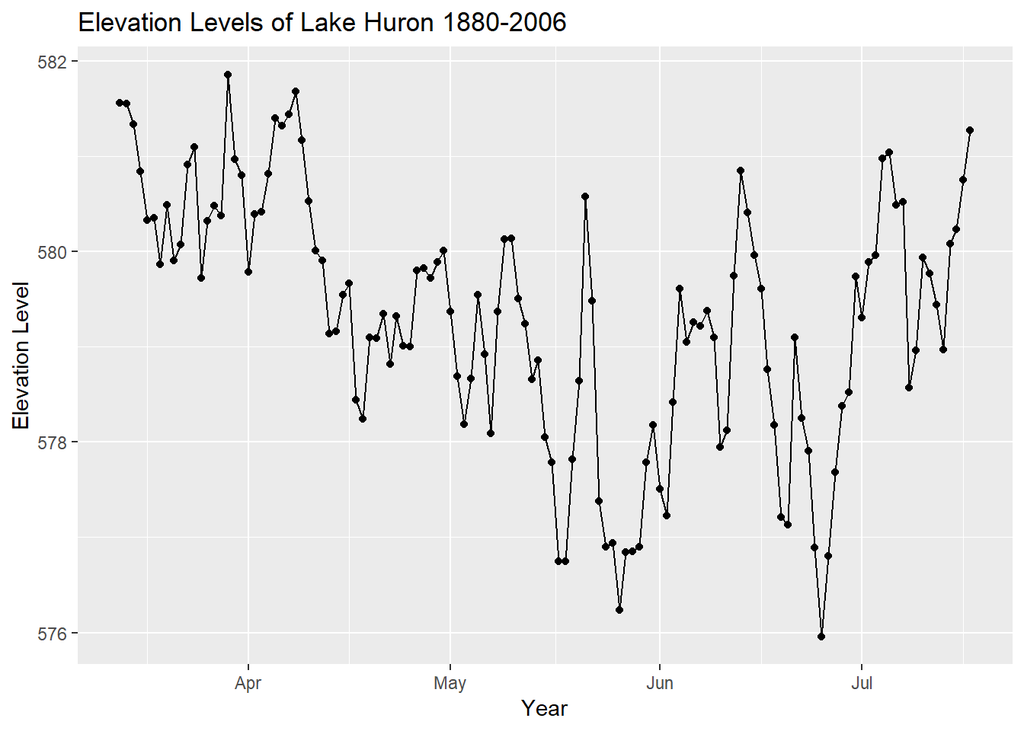

```r
library(tidyverse)
library(forecast)
library(TSA)

huron_data = read_lines("Huron2.txt")

huron_data = as.tibble(huron_data) %>%
  mutate(Year = as.Date(c(1880:2006), origin = "01/01/1880")) %>%
  rename(Elevation = value)

huron_plot = ggplot(huron_data, aes(x = Year, y = as.numeric(Elevation))) +
  geom_point() +
  geom_line() +
  scale_y_continuous() +
  ggtitle("Elevation Levels of Lake Huron 1880-2006") +
  ylab("Elevation Level")
plot(huron_plot)
```

### Part B

*What ARIMA(p,d=0,q) should be fit? Be sure to supply graphs/tables/etc. to support your decision.*

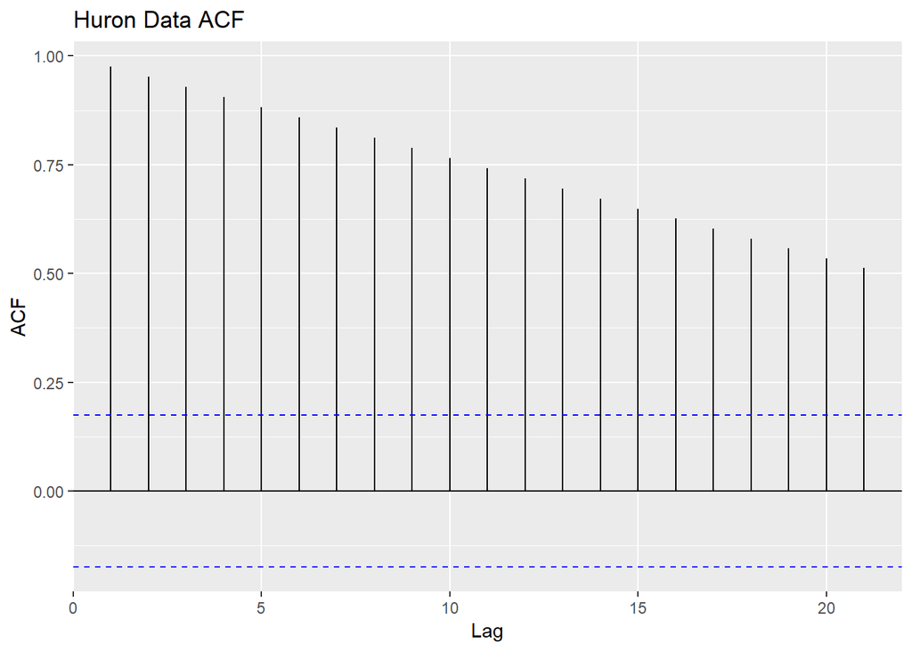

```r
huron_acf = ggAcf(huron_data$Year) +
  ggtitle("Huron Data ACF")
plot(huron_acf)
```

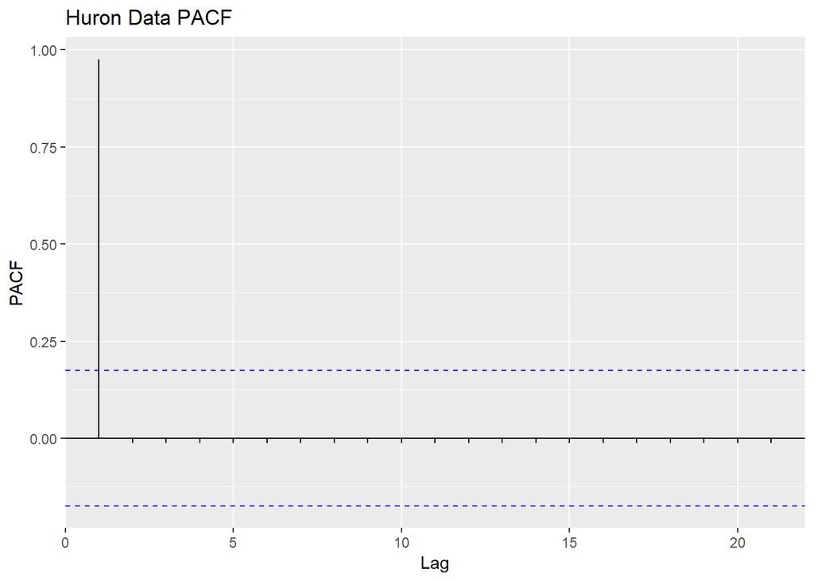

```r
huron_pacf = ggPacf(huron_data$Year) +
  ggtitle("Huron Data PACF")
plot(huron_pacf)
```

```r
huron_ts = ts(as.numeric(huron_data$Elevation), start = c(1880, 1))
eacf(huron_ts)
```

```
## AR/MA
##   0 1 2 3 4 5 6 7 8 9 10 11 12 13
## 0 x x x x x x x x x x x  x  x  x
## 1 x o o o o o o o o o o  o  o  o
## 2 x o o o o o o o o o o  o  o  o
## 3 x o o o o o o o o o o  o  o  o
## 4 x x o o o o o o o o o  o  o  o
## 5 o x x o o o o o o o o  o  o  o
## 6 o x o x o o o o o o o  o  o  o
## 7 o x o x o o o o o o o  o  o  o
```

```r
huron_fit = arima(huron_ts, order = c(1, 0, 0))
huron_fit
```

```
##
## Call:
## arima(x = huron_ts, order = c(1, 0, 0))
##
## Coefficients:
##          ar1  intercept
##       0.8586   579.4918
## s.e.  0.0465     0.4267
##
## sigma^2 estimated as 0.4951:  log likelihood = -136.24,  aic = 276.48
```

```r
huron_fit2 = arima(huron_ts, order = c(1, 0, 1))
huron_fit2
```

```
##
## Call:
## arima(x = huron_ts, order = c(1, 0, 1))
##
## Coefficients:
##          ar1     ma1  intercept
##       0.7967  0.2266   579.4399
## s.e.  0.0642  0.1041     0.3618
##
## sigma^2 estimated as 0.4785:  log likelihood = -134.1,  aic = 274.19
```

```r
huron_fit3 = arima(huron_ts, order = c(2, 0, 1))
huron_fit3
```

```
##
## Call:
## arima(x = huron_ts, order = c(2, 0, 1))
##
## Coefficients:
##          ar1     ar2     ma1  intercept
##       0.0165  0.6990  0.9653   579.4713
## s.e.  0.1762  0.1756  0.1292     0.4063
##
## sigma^2 estimated as 0.4666:  log likelihood = -132.81,  aic = 273.62
```

```r
huron_fit4 = arima(huron_ts, order = c(1, 0, 2))
huron_fit4
```

```
##
## Call:
## arima(x = huron_ts, order = c(1, 0, 2))
##
## Coefficients:
##          ar1     ma1      ma2  intercept
##       0.8278  0.1830  -0.0686   579.4582
## s.e.  0.0844  0.1332   0.1410     0.3886
##
## sigma^2 estimated as 0.4776:  log likelihood = -133.98,  aic = 275.95
```

To confirm an ARIMA(1, 0, 1) is the correct model, I fitted a (1, 0, 2) and found that both MA terms were not significant in this model. Overfitting the (1, 0, 1) model produced results with insignificant terms which supports the decision that the ARIMA(1, 0, 1) is correct.

### Part C

*Check the residuals from your fit suggested in part B. Do they seem to follow a normal distribution and do they seem to be independent?*

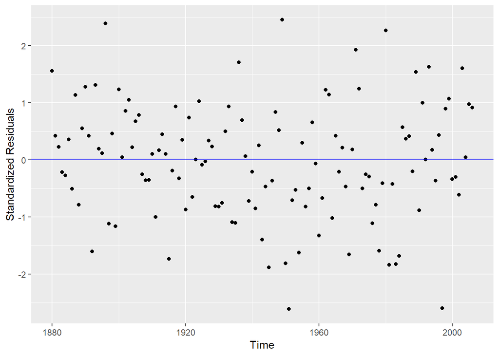

```r
library(gridExtra)
resid = rstandard(huron_fit2)
index = c(1880:2006)

# Dataframe to plot residuals
resid_df = tibble(index, resid)

# Plot of standardized residuals
resid_plot = ggplot(resid_df, aes(x = index, y = resid)) +
  geom_point() +
  geom_hline(yintercept = 0, color = "blue") +
  ylab("Standardized Residuals") +
  xlab("Time")
plot(resid_plot)
```

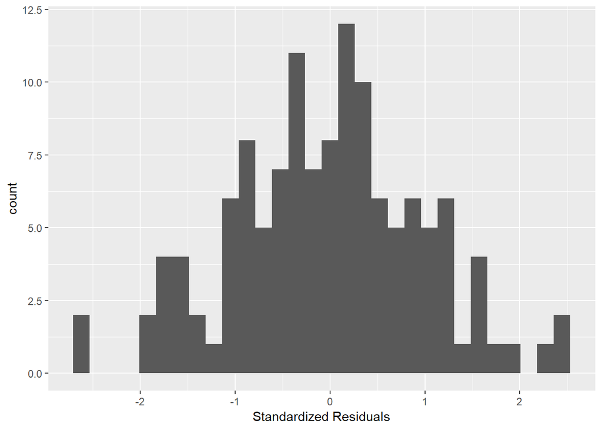

```r
hist_plot = ggplot(resid_df, aes(x = resid)) +
  geom_histogram() +
  xlab("Standardized Residuals")
plot(hist_plot)
```

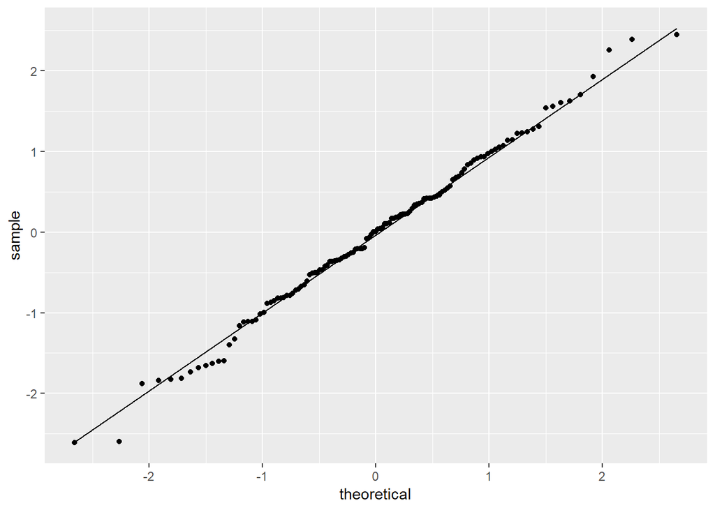

```r
#grid.arrange(resid_plot, hist_plot, ncol = 2)

qq_plot = ggplot(resid_df, aes(sample = resid)) +
  geom_qq() +
  geom_qq_line()
plot(qq_plot)
```

The scatterplot of the residuals vs. time shows a constant variance throughout the series. The histogram and the qqplot both support the assumption of normality for the residuals. The residuals seem to be idependent and normally distributed.

### Part D

*Another way to check for missed patterns is to investigate the ACF of the residuals. Does the ACF suggest a pattern among the sample correlations of the residuals? If so, this is a problem and the model is incorrect. If not, the model’s residuals are again behaving like normally distributed, independent values.*

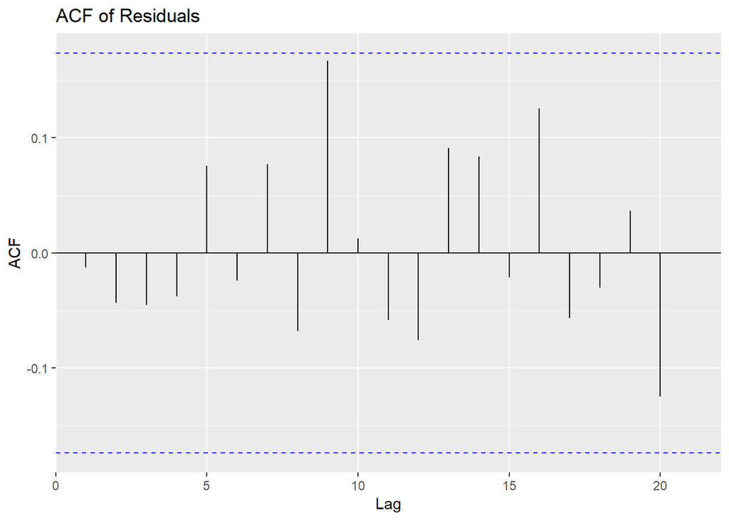

```r
ggAcf(resid) +
  ggtitle("ACF of Residuals")
```

The ACF of the residuals does not appear to suggest a pattern among the residuals

### Part E

*Next, consider the overfitting methods to test model adequacy. Does overfitting support your original model, or does this approach reveal additional terms for the model?*

I didn’t have the forethought to read all the questions when starting this homework assignment, so I did the overfitting of the model in Part B.

### Part F

*Lastly, check the adequacy of the ARIMA model using the Ljung-Box test and the tsdiag output.*

```r
Box.test(residuals(huron_fit2), lag = 10, type = "Ljung-Box", fitdf = 1)
```

```
##
##  Box-Ljung test
##
## data:  residuals(huron_fit2)
## X-squared = 6.938, df = 9, p-value = 0.6436
```

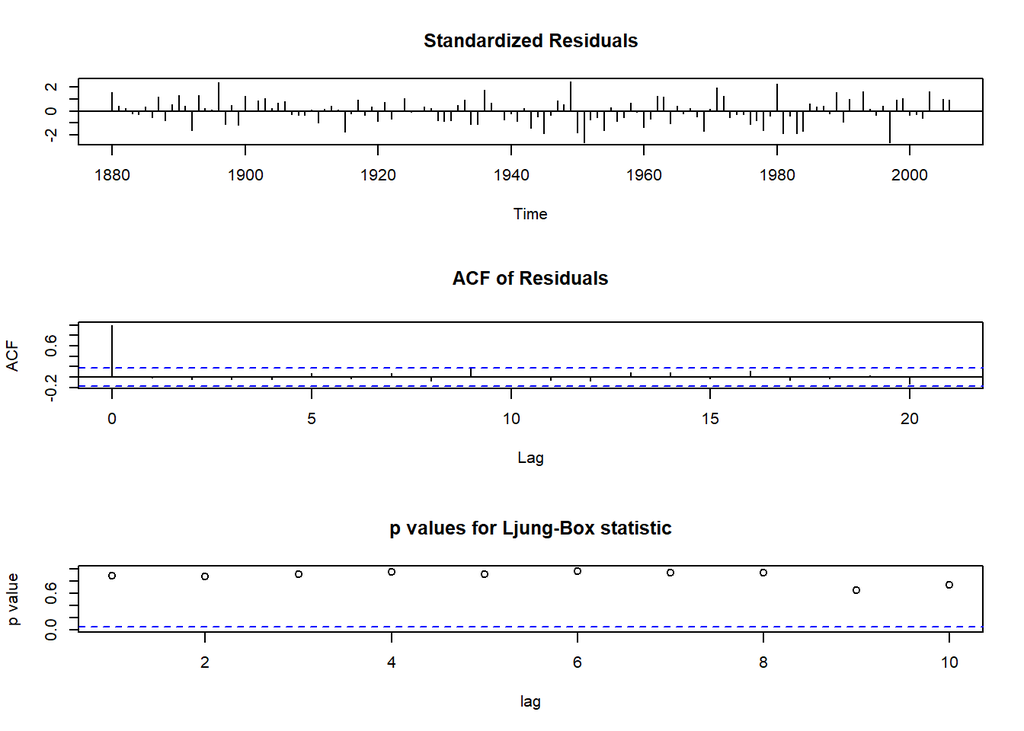

```r
tsdiag(huron_fit2)
```